# Script to prepare data from ReSurvey database v2025.2

Alicia Valdés

03 julio 2026

This R script is used to prepare data of the ReSurvey database for GEE, starting from the raw data downloaded from: https://onedrive.live.com/?redeem=aHR0cHM6Ly8xZHJ2Lm1zL2YvYy8zOWE2ZDZiNzFmMzM1ZTE4L0VoaGVNeC0zMXFZZ2dEbmo0d0lBQUFBQkEwdmo5RjRyYTRnd1VyUGVXQy1UbEE%5FZT1yMUNHVlk&id=39A6D6B71F335E18%21sc5fde9e31e1d49aaab78bfe905b546d1&cid=39A6D6B71F335E18&sb=name&sd=1

# Load libraries

```r
library(tidyverse)
library(here)
library(readxl)
library(sf)
library(cowplot)
```

# Read data

## Data from ReSurveyEurope

```r
data_V2025.2 <- read_tsv(
  "C:/Data/MOTIVATE/MOTIVATE_data/Data/EVA and ReSurvey Data/2025 data - V2025.2/Core data/200_Motivate20250415_notJUICE_header_with_precise_coordinates.csv")
```

No parsing issues!

## Data from DK_Naturdata_Res

```r
db_DK_J<-read_tsv(
  "C:/Data/MOTIVATE/DK_Naturdata_Res_habitat_hab_codes_Jesper/DK_Naturdata_Res_habitat_hab_codes.txt")
```

## Data on correspondences HabitatID (DK_Naturdata_Res) - EUNIS

```r
correspondences<-read_excel(here("..", "DB_first_check", "data", "edited",
                                 "correspondence_HabitatID_DK.xlsx"))
```

# Data preparation ReSurvey

## Keep only the columns needed

```r
data_V2025.2 <- data_V2025.2 %>%
  select(PlotObservationID, Country, `Date of recording`,
         `Expert system`, `ReSurvey plot (Y/N)`, `ReSurvey project`,
         `ReSurvey site`, `ReSurvey plot`, `ReSurvey observation`,
         `Manipulate (y/n)`, `Type of manipulation`, `Location method`,
         RS_CODE, RS_PROJTYP, Dataset, Longitude, Latitude, Lon_prec, Lat_prec)
```

## Filter only ReSurvey part

How many observations are truly resurveyed?

```r
nrow(data_V2025.2 %>% dplyr::filter(!is.na(RS_CODE)))
```

```
[1] 450597
```

```r
# Includes observations in ReSurvey DB
nrow(data_V2025.2 %>% dplyr::filter(`ReSurvey plot (Y/N)` == "Y"))
```

```
[1] 431412
```

```r
# Includes observations in ReSurvey DB that were actually resurveyed
# (i.e. repeated in time) --> Use these
```

```r
data_V2025.2 <- data_V2025.2 %>%
  dplyr::filter(`ReSurvey plot (Y/N)` == "Y") %>%
  select(-`ReSurvey plot (Y/N)`)
```

## Remove manipulated observations

Homogeneize RS_PROJTYP column:

```r
data_V2025.2 %>% count(RS_PROJTYP)
```

| RS_PROJTYP | n |
| --- | --- |
| Permanent (man) | 4456 |
| Resampling | 208 |
| Site comparison | 70 |
| permanent | 323153 |
| permanent (man) | 68130 |
| resampling | 35395 |

```r
data_V2025.2 <- data_V2025.2 %>%
  mutate(RS_PROJTYP = case_when(
    RS_PROJTYP == "Permanent (man)" ~ "permanent (man)",
    RS_PROJTYP == "Resampling" ~ "resampling",
    TRUE  ~ RS_PROJTYP
  ))
data_V2025.2 %>% count(RS_PROJTYP)
```

| RS_PROJTYP | n |
| --- | --- |
| Site comparison | 70 |
| permanent | 323153 |
| permanent (man) | 72586 |
| resampling | 35603 |

```r
nrow(data_V2025.2)
```

```
[1] 431412
```

```r
# Removing all manipulated plots --> Use this
nrow(data_V2025.2 %>% dplyr::filter(RS_PROJTYP != "permanent (man)"))
```

```
[1] 358826
```

```r
# Keep control plots, but `Manipulate (y/n)` == "N" does not always mean
# 'control' in the strict experimental sense
nrow(data_V2025.2 %>%
       dplyr::filter(!(RS_PROJTYP == "permanent (man)" & `Manipulate (y/n)` == "Y")))
```

```
[1] 377573
```

```r
data_V2025.2 <- data_V2025.2 %>%
  dplyr::filter(RS_PROJTYP != "permanent (man)")
nrow(data_V2025.2)
```

```
[1] 358826
```

## Data manipulation

```r
data_V2025.2 <- data_V2025.2 %>%
  # Update coordinates
  mutate(Lon_updated = ifelse(is.na(Lon_prec), Longitude, Lon_prec),
        Lat_updated = ifelse(is.na(Lat_prec), Latitude, Lat_prec)) %>%
  # Remove old coordinate columns
  select(-Longitude, -Latitude, -Lon_prec, -Lat_prec) %>%
  # Remove 459 observations without coordinates
  dplyr::filter(!is.na(Lon_updated)) %>%
  # Translate codes from Location method to words
  # Update `Location method`if edit_loc_method = TRUE
  mutate(`Location method` =
           str_replace_all(
             `Location method`,
             c("01" = "Permanently marked plot isolated (i.e. somewhere within the site)",
               "02" = "Marked plot in a grid (i.e. with regularly spaced neighbor plots)",
               "03" = "Location with differential GPS",
               "04" = "Location with GPS",
               "05" = "Location from accurate map",
               "06" = "Location from a description",
               "07" = "Other",
               "08" = "Marked plot in a transect")), `Location method`) %>%
  # Add columns date and year
  mutate(date = dmy(`Date of recording`), year = as.integer(year(date)))
```

# Clean info on Expert system column and separate it

```r
data_V2025.2 <- data_V2025.2 %>%
  mutate(
    # Clean 'Expert System' column by removing "!" and replacing "~" with NA
    `Expert system` = case_when(
      `Expert system` == "~" ~ NA_character_,  # Replace "~" with NA
      TRUE ~ str_replace_all(`Expert system`, "!", "")  # Remove "!"
    )
  ) %>%
  # Separate the values in 'Expert System' into multiple columns
  separate(
    `Expert system`,
    into = c("EUNISa", "EUNISb", "EUNISc"), # At most, there are 3 diff values
    sep = ",",
    extra = "drop",  # Drop extra values if there are more than columns
    fill = "right",   # Fill missing values with NA for cases with fewer values
    remove = FALSE    # Keep the original 'Expert System' column
  ) %>%
  # Add columns for the different EUNIS levels
  mutate(
    # EUNISa levels
    EUNISa_1 = substr(EUNISa, 1, ifelse(str_starts(EUNISa, "MA"), 2, 1)),
    EUNISa_2 = ifelse(
      nchar(EUNISa) >= ifelse(str_starts(EUNISa, "MA"), 3, 2),
      substr(EUNISa, 1, ifelse(str_starts(EUNISa, "MA"), 3, 2)),
      NA_character_
    ),
    EUNISa_3 = ifelse(
      nchar(EUNISa) >= ifelse(str_starts(EUNISa, "MA"), 4, 3),
      substr(EUNISa, 1, ifelse(str_starts(EUNISa, "MA"), 4, 3)),
      NA_character_
      ),
    EUNISa_4 = ifelse(
      nchar(EUNISa) >= ifelse(str_starts(EUNISa, "MA"), 5, 4),
      substr(EUNISa, 1, ifelse(str_starts(EUNISa, "MA"), 5, 4)),
      NA_character_
    ),
    # EUNISb levels
    EUNISb_1 = substr(EUNISb, 1, ifelse(str_starts(EUNISb, "MA"), 2, 1)),
    EUNISb_2 = ifelse(
      nchar(EUNISb) >= ifelse(str_starts(EUNISb, "MA"), 3, 2),
      substr(EUNISb, 1, ifelse(str_starts(EUNISb, "MA"), 3, 2)),
      NA_character_
    ),
    EUNISb_3 = ifelse(
      nchar(EUNISb) >= ifelse(str_starts(EUNISb, "MA"), 4, 3),
      substr(EUNISb, 1, ifelse(str_starts(EUNISb, "MA"), 4, 3)),
      NA_character_
    ),
    EUNISb_4 = ifelse(
      nchar(EUNISb) >= ifelse(str_starts(EUNISb, "MA"), 5, 4),
      substr(EUNISb, 1, ifelse(str_starts(EUNISb, "MA"), 5, 4)),
      NA_character_
    ),
    # EUNISc levels
    EUNISc_1 = substr(EUNISc, 1, ifelse(str_starts(EUNISc, "MA"), 2, 1)),
    EUNISc_2 = ifelse(
      nchar(EUNISc) >= ifelse(str_starts(EUNISc, "MA"), 3, 2),
      substr(EUNISc, 1, ifelse(str_starts(EUNISc, "MA"), 3, 2)),
      NA_character_
    ),
    EUNISc_3 = ifelse(
      nchar(EUNISc) >= ifelse(str_starts(EUNISc, "MA"), 4, 3),
      substr(EUNISc, 1, ifelse(str_starts(EUNISc, "MA"), 4, 3)),
      NA_character_
    ),
    EUNISc_4 = ifelse(
      nchar(EUNISc) >= ifelse(str_starts(EUNISc, "MA"), 5, 4),
      substr(EUNISc, 1, ifelse(str_starts(EUNISc, "MA"), 5, 4)),
      NA_character_
    )
  )
```

# Add EUNIS from info on HabitatID from DK_Naturdata_Res

## Add info on HabitatID

```r
data_V2025.2 <- data_V2025.2 %>%
  # Keeping all obs in data_V2025.2 but not all in db_DK_J
  left_join(db_DK_J %>% select(PlotObservationID, HabitatID))
```

## Change some Annex I habitat codes that were wrong

```r
data_V2025.2 <- data_V2025.2 %>%
  mutate(HabitatID = as.character(HabitatID)) %>%
  mutate(HabitatID = ifelse(HabitatID == "9998", "91D0",
                            ifelse(HabitatID == "9999", "91E0", HabitatID)))
```

## Add info on correspondences HabitatID (DK_Naturdata_Res) - EUNIS

Add info to data_V2025.2:

```r
data_V2025.2 <- data_V2025.2 %>%
  # Keeping all obs in data_V2025.2
  left_join(correspondences %>% select(HabitatID, EUNIS))
```

Correct NA values in EUNIS

```r
data_V2025.2 <- data_V2025.2 %>%
  mutate(EUNIS = ifelse(EUNIS == "NA", NA, EUNIS))
```

Add info on EUNIS (DK_Naturdata_Res) to EUNISa:

```r
data_V2025.2 <- data_V2025.2 %>%
  mutate(EUNISa =
           # If EUNIS (DK_Naturdata_Res) is available, add as EUNISa
           ifelse(!is.na(EUNIS), EUNIS,
                  # Otherwise keep EUNISa
                  EUNISa),
         EUNIS_assignation = ifelse(!is.na(EUNIS), "Info from DK",
                                    ifelse(is.na(EUNISa), "Not possible",
                                           "Expert system"))) %>%
  # Remove unneeded columns
  select(-EUNIS, -HabitatID)
```

## Update columns for EUNIS levels

Update the columns for the different EUNIS levels:

```r
data_V2025.2 <- data_V2025.2 %>%
  mutate(
    # EUNISa levels
    EUNISa_1 = substr(EUNISa, 1, ifelse(str_starts(EUNISa, "MA"), 2, 1)),
    EUNISa_2 = ifelse(
      nchar(EUNISa) >= ifelse(str_starts(EUNISa, "MA"), 3, 2),
      substr(EUNISa, 1, ifelse(str_starts(EUNISa, "MA"), 3, 2)),
      NA_character_
    ),
    EUNISa_3 = ifelse(
      nchar(EUNISa) >= ifelse(str_starts(EUNISa, "MA"), 4, 3),
      substr(EUNISa, 1, ifelse(str_starts(EUNISa, "MA"), 4, 3)),
      NA_character_
      ),
    EUNISa_4 = ifelse(
      nchar(EUNISa) >= ifelse(str_starts(EUNISa, "MA"), 5, 4),
      substr(EUNISa, 1, ifelse(str_starts(EUNISa, "MA"), 5, 4)),
      NA_character_
    )
  )
```

## Update number of different EUNIS codes

Recalculate how many different EUNIS codes have been assigned:

```r
data_V2025.2 <- data_V2025.2 %>%
  mutate(
    # Count the number of non-NA values across the EUNIS columns
    n_EUNIS = rowSums(!is.na(select(., EUNISa:EUNISc)))
  )
```

New plot for EUNISa_1 (the first assigned EUNIS in cases of multiple assignations, level 1):

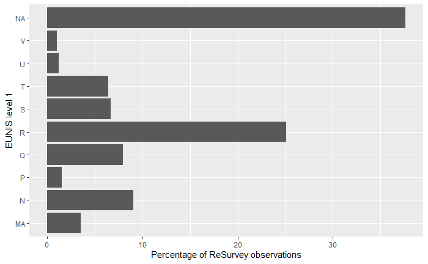

```r
ggplot(data_V2025.2, aes(EUNISa_1)) +
         geom_bar(aes(y = (..count..) / sum(..count..) * 100)) +
  labs(y = "Percentage of ReSurvey observations",
       x = "EUNIS level 1") + coord_flip()
```

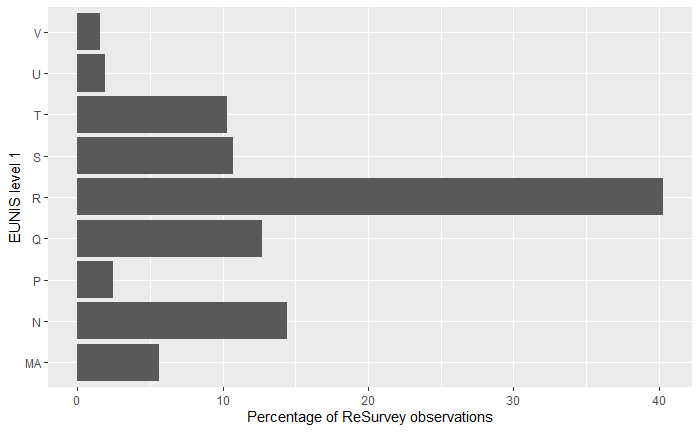

```r
ggplot(data_V2025.2 %>% dplyr::filter(!is.na(EUNISa_1)),
       aes(EUNISa_1)) +
         geom_bar(aes(y = (..count..) / sum(..count..) * 100)) +
  labs(y = "Percentage of ReSurvey observations",
       x = "EUNIS level 1") + coord_flip()
```

# Add descriptions of EUNIS levels

## Level 1

```r
data_V2025.2 <- data_V2025.2 %>%
  mutate(
    EUNISa_1_descr = case_when(
      EUNISa_1 == "V" ~ "Vegetated man-made habitats",
      EUNISa_1 == "U" ~ "Inland habitats with no or little soil",
      EUNISa_1 == "T" ~ "Forests and other wooded land",
      EUNISa_1 == "S" ~ "Heathlands, scrub and tundra",
      EUNISa_1 == "R" ~ "Grasslands",
      EUNISa_1 == "Q" ~ "Wetlands",
      EUNISa_1 == "P" ~ "Inland waters",
      EUNISa_1 == "N" ~ "Coastal habitats",
      EUNISa_1 == "MA" ~ "Marine habitats",
      TRUE ~ NA_character_
    ),
    EUNISb_1_descr = case_when(
      EUNISb_1 == "V" ~ "Vegetated man-made habitats",
      EUNISb_1 == "U" ~ "Inland habitats with no or little soil",
      EUNISb_1 == "T" ~ "Forests and other wooded land",
      EUNISb_1 == "S" ~ "Heathlands, scrub and tundra",
      EUNISb_1 == "R" ~ "Grasslands",
      EUNISb_1 == "Q" ~ "Wetlands",
      EUNISb_1 == "P" ~ "Inland waters",
      EUNISb_1 == "N" ~ "Coastal habitats",
      EUNISb_1 == "MA" ~ "Marine habitats",
      TRUE ~ NA_character_
    ),
    EUNISc_1_descr = case_when(
      EUNISc_1 == "V" ~ "Vegetated man-made habitats",
      EUNISc_1 == "U" ~ "Inland habitats with no or little soil",
      EUNISc_1 == "T" ~ "Forests and other wooded land",
      EUNISc_1 == "S" ~ "Heathlands, scrub and tundra",
      EUNISc_1 == "R" ~ "Grasslands",
      EUNISc_1 == "Q" ~ "Wetlands",
      EUNISc_1 == "P" ~ "Inland waters",
      EUNISc_1 == "N" ~ "Coastal habitats",
      EUNISc_1 == "MA" ~ "Marine habitats",
      TRUE ~ NA_character_
    )
  )
```

## Level 2

```r
descriptions<-read_excel(here("..", "DB_first_check", "data", "edited",
                                 "EUNIS-Habitats-2021-06-01_modified.xlsx"))
```

```r
# Define the columns and corresponding description column names
eunis_cols <- c("EUNISa_2", "EUNISa_3", "EUNISa_4",
                "EUNISb_2", "EUNISb_3", "EUNISb_4",
                "EUNISc_2", "EUNISc_3", "EUNISc_4")

# Create corresponding description column names
descr_col_names <- paste0(eunis_cols, "_descr")

# Use reduce to loop through the columns and join dynamically based on level
data_V2025.2 <- reduce(seq_along(eunis_cols), function(data, i) {
  # Extract level number from the column name (e.g., EUNISa_2 -> 2)
  level <- as.numeric(gsub("\\D", "", eunis_cols[i]))

  # Filter descriptions for the corresponding level
  descriptions_level <- descriptions %>%
    dplyr::filter(level == level) %>%
    select(`EUNIS 2020 code`, `EUNIS-2021 habitat name`)

  # Perform the left_join and rename the column dynamically
  data %>%
    left_join(
      descriptions_level,
      by = setNames("EUNIS 2020 code", eunis_cols[i])
    ) %>%
    rename(!!descr_col_names[i] := `EUNIS-2021 habitat name`)
}, .init = data_V2025.2)
```

See where matching did not work:

```r
data_V2025.2 %>%
  dplyr::filter(!is.na(EUNISa_2) & is.na(EUNISa_2_descr)) %>% count(EUNISa_2)
```

| EUNISa_2 | n |
| --- | --- |
| P2 | 127 |
| P3 | 977 |
| Pb | 4321 |
| Pe | 3 |
| Pi | 3 |
| Q6 | 54 |
| Qa | 393 |
| Qb | 611 |
| R3 | 11673 |
| R4 | 3409 |

[output cut: 4 more lines]

```r
data_V2025.2 %>%
  dplyr::filter(!is.na(EUNISa_3) & is.na(EUNISa_3_descr)) %>% count(EUNISa_3)
```

| EUNISa_3 | n |
| --- | --- |
| P2N | 127 |
| P3a | 27 |
| P3b | 47 |
| P3c | 46 |
| P3d | 562 |
| P3e | 178 |
| P3f | 54 |
| P3g | 4 |
| P3h | 59 |
| Q61 | 32 |

[output cut: 2 more lines]

```r
data_V2025.2 %>%
  dplyr::filter(!is.na(EUNISa_4) & is.na(EUNISa_4_descr)) %>% count(EUNISa_4)
```

| EUNISa_4 | n |
| --- | --- |

The matching did not work sometimes, correct!

```r
# Correct EUNISa levels 2-4 descriptions
data_V2025.2 <- data_V2025.2 %>%
  mutate(EUNISa_2_descr =
           ifelse(!is.na(EUNISa_2_descr), EUNISa_2_descr,
                  case_when(
                    EUNISa_2 == "P2" ~ "Running aquatic habitats",
                    EUNISa_2 == "P3" ~ "Aquatic plant communities",
                    EUNISa_2 == "Pf" ~ "Fresh-water submerged vegetation",
                    EUNISa_2 == "Pj" ~ "Stonewort vegetation",
                    EUNISa_2 == "R4" ~ "Alpine and subalpine grasslands",
                    EUNISa_2 == "Pb" ~ "Calcareous spring and spring brook",
                    EUNISa_2 == "Qb" ~ "Wetlands",
                    EUNISa_2 == "R3" ~ "Seasonally wet and wet grasslands",
                    EUNISa_2 == "Qa" ~ "Mires",
                    EUNISa_2 == "Pa" ~ "Base-poor spring and spring brook",
                    EUNISa_2 == "Ph" ~ "Oligotrophic-water vegetation",
                    EUNISa_2 == "Pg" ~ "Fresh-water nymphaeid vegetation",
                    EUNISa_2 ==
                      "Pd" ~ "Fresh-water small pleustophyte vegetation",
                    EUNISa_2 == "Pc" ~ "Brackish-water vegetation",
                    EUNISa_2 ==
                      "Pe" ~ "Fresh-water large pleustophyte vegetation",
                    EUNISa_2 == "Pi" ~ "Dystrophic-water vegetation",
                    EUNISa_2 == "S1" ~ "Tundra",
                    EUNISa_2 ==
                      "U7" ~ "Unvegetated or sparsely vegetated gravel bars",
                    EUNISa_2 == "Q6" ~ "Periodically exposed shores",
                    EUNISa_2 == "R3" ~ "Seasonally wet and wet grasslands",
                    EUNISa_2 == "R4" ~ "Alpine and subalpine grasslands",
                    EUNISa_2 == "U7" ~ "Unvegetated or sparsely vegetated gravel bars",
                    # Sa & Sb, not sure what these are, left without description
                    TRUE ~ NA_character_)
                  ),
         EUNISa_3_descr =
           ifelse(!is.na(EUNISa_3_descr), EUNISa_3_descr,
                  case_when(
                    EUNISa_3 =="U71" ~ "Unvegetated or sparsely vegetated gravel bar in montane and alpine regions",
                    EUNISa_3 =="Q61" ~ "Periodically exposed shore with stable, eutrophic sediments with pioneer or ephemeral vegetation",
                    EUNISa_3 =="Q62" ~ "Periodically exposed shore with stable, mesotrophic sediments with pioneer or ephemeral vegetation",
                    EUNISa_3 == "P2N" ~ "Spring",
                    EUNISa_3 == "P3a" ~ "Brackish-water vegetation",
                    EUNISa_3 == "P3b" ~ "Fresh-water small pleustophyte vegetation",
                    EUNISa_3 == "P3c" ~ "Fresh-water large pleustophyte vegetation",
                    EUNISa_3 == "P3d" ~ "Fresh-water submerged vegetation",
                    EUNISa_3 == "P3e" ~ "Fresh-water nymphaeid vegetation",
                    EUNISa_3 == "P3f" ~ "Oligotrophic-water vegetation",
                    EUNISa_3 == "P3g" ~ "Dystrophic-water vegetation",
                    EUNISa_3 == "P3h" ~ "Stonewort vegetation",
                    TRUE ~ NA_character_
                    ))
         )
```

# Remove EUNIS cols that are all NA

```r
data_V2025.2 %>% dplyr::filter(!is.na(EUNISb_4))
```

| PlotObservationID | Country | Date of recording | Expert system | EUNISa | EUNISb | EUNISc | ReSurvey project | ReSurvey site | ReSurvey plot | ReSurvey observation | Manipulate (y/n) | Type of manipulation | Location method | RS_CODE | RS_PROJTYP | Dataset | Lon_updated | Lat_updated | date | year | EUNISa_1 | EUNISa_2 | EUNISa_3 | EUNISa_4 | EUNISb_1 | EUNISb_2 | EUNISb_3 | EUNISb_4 | EUNISc_1 | … |
| --- | --- | --- | --- | --- | --- | --- | --- | --- | --- | --- | --- | --- | --- | --- | --- | --- | --- | --- | --- | --- | --- | --- | --- | --- | --- | --- | --- | --- | --- | --- |

```r
data_V2025.2 %>% dplyr::filter(!is.na(EUNISc_4))
```

| PlotObservationID | Country | Date of recording | Expert system | EUNISa | EUNISb | EUNISc | ReSurvey project | ReSurvey site | ReSurvey plot | ReSurvey observation | Manipulate (y/n) | Type of manipulation | Location method | RS_CODE | RS_PROJTYP | Dataset | Lon_updated | Lat_updated | date | year | EUNISa_1 | EUNISa_2 | EUNISa_3 | EUNISa_4 | EUNISb_1 | EUNISb_2 | EUNISb_3 | EUNISb_4 | EUNISc_1 | … |
| --- | --- | --- | --- | --- | --- | --- | --- | --- | --- | --- | --- | --- | --- | --- | --- | --- | --- | --- | --- | --- | --- | --- | --- | --- | --- | --- | --- | --- | --- | --- |

```r
data_V2025.2 <- data_V2025.2 %>% select(-EUNISb_4, -EUNISc_4,
                                        -EUNISb_4_descr, -EUNISc_4_descr)
```

# Remove EUNIS cols and other cols that will not be used

```r
data_V2025.2 <- data_V2025.2 %>%
  select(-`Date of recording`, -`Expert system`, -EUNISa , -EUNISb, -EUNISc,
         -`Manipulate (y/n)`, -`Type of manipulation`)
```

# Remove obs where there are multiple assignments at EUNIS level 1

See PlotObservationIDs for those rows:

```r
multiple_assign <- data_V2025.2 %>%
  dplyr::filter(!is.na(EUNISb_1) & EUNISb_1 != EUNISa_1) %>%
  pull(PlotObservationID)
```

```r
data_V2025.2 <- data_V2025.2 %>%
  dplyr::filter(!PlotObservationID %in% multiple_assign)
```

# Identify ESY columns

Add “ESY_” before all EUNIS columns that come from the Expert system or from info from DK.

```r
data_V2025.2 <- data_V2025.2 %>%
  rename_with(~ gsub("EUNIS", "ESY_EUNIS", .x), contains("EUNIS"))
```

# Add Pl@ntBert predictions

## Abundance

```r
plantbert_ab <- read_csv(
  "C:/Data/MOTIVATE/Pl@ntBERT/plantbert_habitat_predictions.csv")
```

```r
nrow(plantbert_ab)
```

```
[1] 900940
```

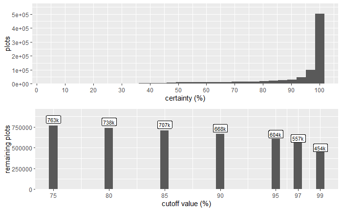

```r
# Code adapted from Michael (Data_Cleaning_20251027_Michael.Rmd)
# Normalize column names
colnames(plantbert_ab) <- gsub(" ", ".", colnames(plantbert_ab))

# Compute the top-level EUNIS (level-2) code (2 characters)
plantbert_ab$top.lvl2 <- substr(
  plantbert_ab$`Most.likely.EUNIS.level-2.habitat`, 1, 2)
plantbert_ab$top.lvl2 <- gsub("MA", "M2", plantbert_ab$top.lvl2)

# Extract the certainty percentage as a numeric value
plantbert_ab$top.lvl2.perc <- as.numeric(
  sub(".*\\(([^%]+)%\\).*", "\\1",
      plantbert_ab$`Most.likely.EUNIS.level-2.habitat`))

# Label this dataset’s method
plantbert_ab$PB_method <- "PB_abund"

# Define cutoff thresholds
cutoff <- c(75, 80,  85, 90, 95, 97, 99)

# Compute how many rows remain above each cutoff
plantbert_ab.cutoff <- plantbert_ab %>%
  dplyr::reframe(cutoff = cutoff,
                 n.remaining = sapply(cutoff,
                                      function (c) sum(top.lvl2.perc >= c)))

# Plot the histogram of certainty values
plot.pb.hist <- ggplot(plantbert_ab) +
  geom_histogram(aes(x = top.lvl2.perc)) +
  scale_x_continuous(breaks = seq(0, 100, 10)) +
  scale_y_continuous(expand = expansion(mult = c(0, 0.15))) +
  labs(x = "certainty (%)", y = "plots")

# Plot the remaining rows by cutoff
plot.pb.cutoff <- ggplot(plantbert_ab.cutoff) +
  geom_bar(aes(x = cutoff, y = n.remaining), stat = "identity", width = 0.75) +
  scale_x_continuous(breaks = cutoff) +
  scale_y_continuous(expand = expansion(mult = c(0, 0.15))) +
  geom_label(aes(x = cutoff, y = n.remaining * 1.1,
                 label = paste0(round(n.remaining / 1000), "k")),
             size = 3) +
    labs(x = "cutoff value (%)", y = "remaining plots")

# Combine both plots vertically
grid.pb <- plot_grid(plot.pb.hist, plot.pb.cutoff, nrow = 2)
grid.pb
```

```r
# Choose a final cutoff and filter the data
pb.cut.abund <- 75

plantbert_ab <- plantbert_ab %>%
  dplyr::filter(top.lvl2.perc >= pb.cut.abund) %>%
  mutate(PB_method = "PB_abund")

nrow(plantbert_ab)
```

```
[1] 763322
```

```r
plantbert_ab <- plantbert_ab %>%
  # Keep columns needed
  select(PlotObservationID, top.lvl2, top.lvl2.perc, PB_method) %>%
  # Rename columns
  rename(PB_EUNIS = top.lvl2, PB_EUNIS_perc = top.lvl2.perc)
```

## Pres-abs

```r
plantbert_pa <- read_csv(
  "C:/Data/MOTIVATE/Pl@ntBERT/plantbert_habitat_predictions_random.csv")
```

```r
nrow(plantbert_pa)
```

```
[1] 370138
```

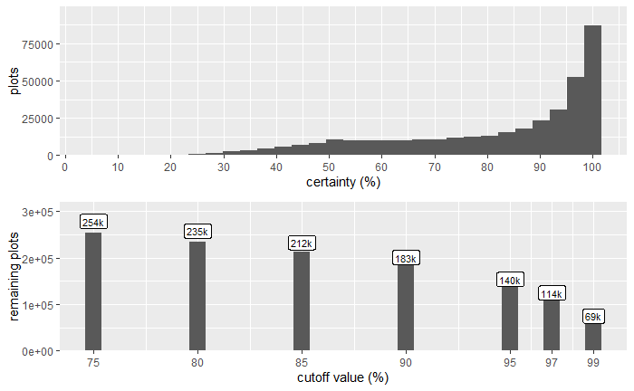

```r
# Code adapted from Michael (Data_Cleaning_20251027_Michael.Rmd)
# Normalize column names
colnames(plantbert_pa) <- gsub(" ", ".", colnames(plantbert_pa))

# Compute the top-level EUNIS (level-2) code (2 characters)
plantbert_pa$top.lvl2 <- substr(
  plantbert_pa$`Most.likely.EUNIS.level-2.habitat`, 1, 2)
plantbert_pa$top.lvl2 <- gsub("MA", "M2", plantbert_pa$top.lvl2)

# Extract the certainty percentage as a numeric value
plantbert_pa$top.lvl2.perc <- as.numeric(
  sub(".*\\(([^%]+)%\\).*", "\\1",
      plantbert_pa$`Most.likely.EUNIS.level-2.habitat`))

# Label this dataset’s method
plantbert_pa$PB_method <- "PB_presabs"

# Define cutoff thresholds
cutoff <- c(75, 80,  85, 90, 95, 97, 99)

# Compute how many rows remain above each cutoff
plantbert_pa.cutoff <- plantbert_pa %>%
  dplyr::reframe(cutoff = cutoff,
                 n.remaining = sapply(cutoff,
                                      function (c) sum(top.lvl2.perc >= c)))

# Plot the histogram of certainty values
plot.pb.pa.hist <- ggplot(plantbert_pa) +
  geom_histogram(aes(x = top.lvl2.perc)) +
  scale_x_continuous(breaks = seq(0, 100, 10)) +
  scale_y_continuous(expand = expansion(mult = c(0, 0.15))) +
  labs(x = "certainty (%)", y = "plots")

# Plot the remaining rows by cutoff
plot.pb.pa.cutoff <- ggplot(plantbert_pa.cutoff) +
  geom_bar(aes(x = cutoff, y = n.remaining), stat = "identity", width = 0.75) +
  scale_x_continuous(breaks = cutoff) +
  scale_y_continuous(expand = expansion(mult = c(0, 0.15))) +
  geom_label(aes(x = cutoff, y = n.remaining * 1.1,
                 label = paste0(round(n.remaining / 1000), "k")),
             size = 3) +
    labs(x = "cutoff value (%)", y = "remaining plots")

# Combine both plots vertically
grid.pb.pa <- plot_grid(plot.pb.pa.hist, plot.pb.pa.cutoff, nrow = 2)
grid.pb.pa
```

```r
# Choose a final cutoff and filter the data
# Michael: We can't  choose the same accuracy cutoff for both datasets,
# because their global accuracy is different (0.92 versus 0.78).
# So by scaling pb.cut.abund by the quotient of the global accuracies
# we are at least achieving some statistical cohesion.
# Thinking based on model weighting using various indices...
pb.cut.pa <- pb.cut.abund * 0.92/0.78

plantbert_pa <- plantbert_pa %>%
  dplyr::filter(top.lvl2.perc >= pb.cut.pa) %>%
  mutate(PB_method = "PB_presabs")

nrow(plantbert_pa)
```

```
[1] 193243
```

```r
plantbert_pa <- plantbert_pa %>%
  # Keep columns needed
  select(PlotObservationID, top.lvl2, top.lvl2.perc, PB_method) %>%
  # Rename columns
  rename(PB_EUNIS = top.lvl2, PB_EUNIS_perc = top.lvl2.perc)
```

## Check how many observations are in common between the two datasets

```r
any(plantbert_pa$PlotObservationID %in% plantbert_ab$PlotObservationID)
```

```
[1] FALSE
```

No common observations.

## Merge with previous data

```r
data_V2025.2 <- data_V2025.2 %>%
  left_join(rbind(plantbert_ab, plantbert_pa)) %>%
    # Add columns for the different EUNIS levels
  mutate(
    # EUNISa levels
    PB_EUNIS_1 = substr(PB_EUNIS, 1, ifelse(str_starts(PB_EUNIS, "MA"), 2, 1)),
    PB_EUNIS_2 = ifelse(
      nchar(PB_EUNIS) >= ifelse(str_starts(PB_EUNIS, "MA"), 3, 2),
      substr(PB_EUNIS, 1, ifelse(str_starts(PB_EUNIS, "MA"), 3, 2)),
      NA_character_)
    ) %>%
  select(-PB_EUNIS)
```

## See differences in level 1 between ESY and PB

```r
data_V2025.2 %>% dplyr::filter(ESY_EUNISa_1 != PB_EUNIS_1) %>% nrow()
```

```
[1] 5292
```

# Almost final EUNIS1 and EUNIS2

```r
data_V2025.2 <- data_V2025.2 %>%
  mutate(
    # Final EUNIS level 1 (option 1): If ESY is available, use it,
    # otherwise use PB
    EUNIS1_dk = ifelse(!is.na(ESY_EUNISa_1), ESY_EUNISa_1, PB_EUNIS_1),
    # Final EUNIS level 1 (option 2): If ESY is available
    # and habitat assignation is from the Expert system, use it,
    # otherwise use PB
    EUNIS1_pb = ifelse(!is.na(ESY_EUNISa_1) &
                         ESY_EUNIS_assignation == "Expert system",
                       ESY_EUNISa_1, PB_EUNIS_1),
    # Final EUNIS level 2 (option 1): If ESY is available, use it,
    # otherwise use PB
    EUNIS2_dk = ifelse(!is.na(ESY_EUNISa_1), ESY_EUNISa_2, PB_EUNIS_2),
    # Final EUNIS level 2 (option 2): If ESY is available
    # and habitat assignation is from the Expert system, use it,
    # otherwise use PB
    EUNIS2_pb = ifelse(!is.na(ESY_EUNISa_1) &
                         ESY_EUNIS_assignation == "Expert system",
                       ESY_EUNISa_2, PB_EUNIS_2)
  )
```

# Numbers of total observations

```r
# With ESY
data_V2025.2 %>% dplyr::filter(!is.na(ESY_EUNISa_1)) %>% nrow()
```

```
[1] 223485
```

```r
# With PB
data_V2025.2 %>% dplyr::filter(!is.na(PB_EUNIS_1)) %>% nrow()
```

```
[1] 132759
```

```r
# With mix ESY-PB (dk)
data_V2025.2 %>% dplyr::filter(!is.na(EUNIS1_dk)) %>% nrow() # Higher number of obs
```

```
[1] 322164
```

```r
# With mix ESY-PB (pb)
data_V2025.2 %>% dplyr::filter(!is.na(EUNIS1_pb)) %>% nrow()
```

```
[1] 208258
```

# Numbers of observations in Q. R, S, T

```r
# With ESY
data_V2025.2 %>% dplyr::filter(ESY_EUNISa_1 %in% c("Q", "R", "S", "T")) %>% nrow()
```

```
[1] 165381
```

```r
# With PB
data_V2025.2 %>% dplyr::filter(PB_EUNIS_1 %in% c("Q", "R", "S", "T")) %>% nrow()
```

```
[1] 112441
```

```r
# With mix ESY-PB (dk)
data_V2025.2 %>% dplyr::filter(EUNIS1_dk %in% c("Q", "R", "S", "T")) %>% nrow() # Higher number of obs
```

```
[1] 245596
```

```r
# With mix ESY-PB (pb)
data_V2025.2 %>% dplyr::filter(EUNIS1_pb %in% c("Q", "R", "S", "T")) %>% nrow()
```

```
[1] 177723
```

# Difference between EUNIS1_dk and EUNIS1_pb

```r
# At level 1
data_V2025.2 %>%
  dplyr::filter(ESY_EUNIS_assignation == "Info from DK") %>%
  nrow()
```

```
[1] 116066
```

```r
data_V2025.2 %>%
  dplyr::filter(ESY_EUNIS_assignation == "Info from DK") %>%
  dplyr::filter(EUNIS1_dk != EUNIS1_pb) %>% nrow()
```

```
[1] 1995
```

```r
# At level 2
data_V2025.2 %>%
  dplyr::filter(ESY_EUNIS_assignation == "Info from DK") %>%
  nrow()
```

```
[1] 116066
```

```r
data_V2025.2 %>%
  dplyr::filter(ESY_EUNIS_assignation == "Info from DK") %>%
  dplyr::filter(EUNIS2_dk != EUNIS2_pb) %>% nrow()
```

```
[1] 1994
```

# Final EUNIS1 and EUNIS2

```r
data_V2025.2 <- data_V2025.2 %>%
  # Create new cols with final EUNIS based on:
  # 1) ESy, 2) Annex I crosswalk, 3) Pl@ntBert
  # (keep other cols for reference)
  mutate(EUNIS1 = EUNIS1_dk, EUNIS2 = EUNIS2_dk)
```

# (Appendix 1) Distribution of observations among habitat assignation methods

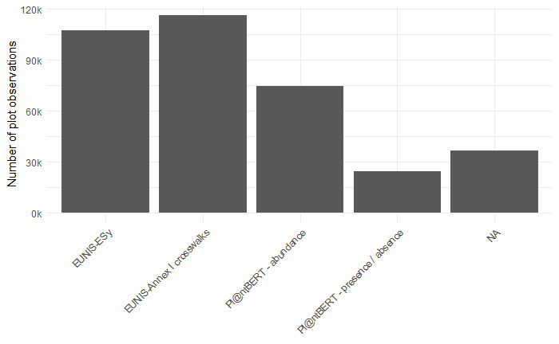

```r
data_V2025.2 %>%
  mutate(category = case_when(
    ESY_EUNIS_assignation == "Expert system" ~ "EUNIS-ESy",
    ESY_EUNIS_assignation == "Info from DK" ~ "EUNIS-Annex I crosswalks",
    ESY_EUNIS_assignation == "Not possible" & PB_method == "PB_abund" ~ "Pl@ntBERT - abundance",
    ESY_EUNIS_assignation == "Not possible" & PB_method == "PB_presabs" ~ "Pl@ntBERT - presence / absence",
    ESY_EUNIS_assignation == "Not possible" & is.na(PB_method) ~ "NA"
  )) %>%
  count(category) %>%
  mutate(category = factor(
    category,
    levels = c(
      "EUNIS-ESy",
      "EUNIS-Annex I crosswalks",
      "Pl@ntBERT - abundance",
      "Pl@ntBERT - presence / absence",
      "NA"
    )
  )) %>%
  ggplot(aes(x = category, y = n)) +
  geom_col() +
  theme_minimal() +
  theme(axis.text.x = element_text(angle = 45, hjust = 1)) +
  scale_y_continuous(labels = scales::label_number(scale = 1e-3, suffix = "k")) +
  labs(
    x = NULL,
    y = "Number of plot observations"
  )
ggsave(here("output", "figures", "manuscript", "appendix1.jpeg"),
       dpi = 300, width = 4, height = 4)
```

# Keep only Q, R, S, T

```r
data_V2025.2 <- data_V2025.2 %>% dplyr::filter(EUNIS1 %in% c("Q", "R", "S", "T"))
```

# Descriptives

Number of observations:

```r
data_V2025.2 %>% nrow()
```

```
[1] 245596
```

Number of plots (i.e. unique combinations of RS_CODE, ReSurvey site and ReSurvey plot):

```r
data_V2025.2 %>%
  group_by(RS_CODE, `ReSurvey site`, `ReSurvey plot`) %>%
  count() %>%
  nrow()
```

```
[1] 90263
```

BUT there are cases with different coordinates within the same plot, not at all sure about this number, ask Illona.

# Habitat assignation

```r
data_V2025.2 <- data_V2025.2 %>%
  mutate(EUNIS_assignation = ifelse(ESY_EUNIS_assignation == "Not possible",
                                    "Pl@ntBert", ESY_EUNIS_assignation))
```

```r
data_V2025.2 %>%
  count(EUNIS_assignation) %>%
  mutate(percentage = round(n*100 / sum(n)))
```

| EUNIS_assignation | n | percentage |
| --- | --- | --- |
| Expert system | 95767 | 39 |
| Info from DK | 69614 | 28 |
| Pl@ntBert | 80215 | 33 |

Cases where the expert system assigned more than one EUNIS habitat type at level 1: Removed already!

```r
data_V2025.2 %>%
  dplyr::filter(!is.na(ESY_EUNISb_1) & ESY_EUNISa_1 != ESY_EUNISb_1)
```

| PlotObservationID | Country | ReSurvey project | ReSurvey site | ReSurvey plot | ReSurvey observation | Location method | RS_CODE | RS_PROJTYP | Dataset | Lon_updated | Lat_updated | date | year | ESY_EUNISa_1 | ESY_EUNISa_2 | ESY_EUNISa_3 | ESY_EUNISa_4 | ESY_EUNISb_1 | ESY_EUNISb_2 | ESY_EUNISb_3 | ESY_EUNISc_1 | ESY_EUNISc_2 | ESY_EUNISc_3 | ESY_EUNIS_assignation | n_ESY_EUNIS | ESY_EUNISa_1_descr | ESY_EUNISb_1_descr | ESY_EUNISc_1_descr | ESY_EUNISa_2_descr | … |
| --- | --- | --- | --- | --- | --- | --- | --- | --- | --- | --- | --- | --- | --- | --- | --- | --- | --- | --- | --- | --- | --- | --- | --- | --- | --- | --- | --- | --- | --- | --- |

# Remove spatial duplicates

Spatial duplicates are plots have the same exact coordinates, because the surveyor did several plots at one location, and just recorded a pair of coordinates.

If a group of spatial duplicates has different habitats at EUNIS level 1 (column EUNIS1) -discard the whole group of plots. If a group of spatial duplicates has the same habitat at EUNIS level 1 (column EUNIS1) - keep just one of the plots.

```r
spatial_groups <- data_V2025.2 %>%
  # Identify the plots
  group_by(RS_CODE, `ReSurvey site`, `ReSurvey plot`) %>%
  # unique numeric ID for each plot combination
  mutate(plot_id = cur_group_id()) %>%
  # Calculate number of distinct EUNIS1 assignations for the plot
  mutate(n_EUNIS1_plot = n_distinct(EUNIS1)) %>%
  # Calculate EUNIS1 for the plot:
  # If multiple observations for each plot, with the same EUNIS1,
  # keep that EUNIS1, otherwise assign "mixed" to EUNIS1
  mutate(EUNIS1_plot = ifelse(n_EUNIS1_plot == 1, first(EUNIS1), "mixed")) %>%
  ungroup() %>%
  # Group by coordinates to find spatial duplicates
  group_by(Lat_updated, Lon_updated) %>%
  # unique numeric ID for each coordinates combination
  mutate(coord_id = cur_group_id()) %>%
  mutate(
    # number of distinct plots at these coords
    n_plots = n_distinct(plot_id),
    # number of distinct EUNIS1_plot values at these coords
    n_EUNIS1_coords = n_distinct(EUNIS1_plot),
    ) %>%
  # When there are several plots at the same coordinates,
  # and the number of distinct EUNIS_plot values at these coords is 1,
  # but EUNIS1_plot is "mixed",
  # then we have a mixed-habitat group, so assign "mixed" to EUNIS1_coords
  mutate(
    n_EUNIS1_coords_real = ifelse(
      n_plots > 1 & n_EUNIS1_coords == 1 & EUNIS1_plot == "mixed",
      "mixed", as.character(n_EUNIS1_coords))
    ) %>%
  ungroup()

# Identify spatial duplicates

## A) Mixed-habitat groups → discard whole groups
discard_mixed <- spatial_groups %>%
  # We only want to keep groups of spatial duplicates with the same EUNIS1,
  # so we discard the ones with more than one EUNIS1 at the coordinates,
  # but we also want to discard the ones with several plots at the same
  # coordinates but with "mixed" EUNIS1_plot,
  # because they are also mixed-habitat groups
  dplyr::filter(n_plots > 1 & n_EUNIS1_coords_real != 1)

## B) Same-habitat groups → collapse to 1 plot
same_habitat <- spatial_groups %>%
  dplyr::filter(n_plots > 1 & n_EUNIS1_coords_real == 1)

# keep one arbitrary plot per coordinate location
collapsed_same <- same_habitat %>%
  group_by(coord_id) %>%
  slice(1) %>%      # OR: slice_min(year), slice_max(date), etc.
  ungroup() %>%
  # Add column to indicate that these were collapsed from several plots
  mutate(collapsed_from = n_plots)

## C) Unique plots (no spatial duplicates)
unique_plots <- spatial_groups %>%
  dplyr::filter(n_plots == 1) %>%
  # Add column to indicate that these were unique plots
  mutate(collapsed_from = 1)

# Final cleaned dataset
data_V2025.2_clean <- bind_rows(
  unique_plots,
  collapsed_same
) %>%
  arrange(plot_id) %>%     # optional
  ungroup()
```

Counts:

```r
n_coord_total <- spatial_groups %>% distinct(coord_id) %>% nrow()

n_coord_discard_mixed <- discard_mixed %>% distinct(coord_id) %>% nrow()
n_coord_same_habitat  <- same_habitat  %>% distinct(coord_id) %>% nrow()
n_coord_unique        <- unique_plots  %>% distinct(coord_id) %>% nrow()

cat("Total number of coordinate groups: ", n_coord_total, "\n")
```

```
Total number of coordinate groups:  77479
```

```r
cat("Coordinate groups discarded due to mixed habitats: ", n_coord_discard_mixed, "\n")
```

```
Coordinate groups discarded due to mixed habitats:  10928
```

```r
cat("Coordinate groups kept by collapsing same‑habitat duplicates: ", n_coord_same_habitat, "\n")
```

```
Coordinate groups kept by collapsing same‑habitat duplicates:  5056
```

```r
cat("Unique coordinate groups with no spatial duplicates: ", n_coord_unique, "\n")
```

```
Unique coordinate groups with no spatial duplicates:  61495
```

```r
cat("Original number of plots: ", data_V2025.2 %>%
      group_by(RS_CODE, `ReSurvey site`, `ReSurvey plot`) %>%
      mutate(plot_id = cur_group_id()) %>% distinct(plot_id) %>% nrow(), "\n")
```

```
Original number of plots:  90263
```

```r
cat("Final number of plots: ", data_V2025.2_clean %>% distinct(plot_id) %>% nrow(), "\n")
```

```
Final number of plots:  58604
```

```r
n_coord_total == (n_coord_discard_mixed + n_coord_same_habitat + n_coord_unique)
```

```
[1] TRUE
```